# Leave-One-Out Brier Score for Bayesian Survival Models

Using Pareto smoothed importance sampling

Eren M. Elçi

2018-12-02

In this short case study I show how to implement an estimator for the leave-one-out (LOO) version of the Expected Brier Score for Bayesian Survival Models, with right-censored event times. We utilize the so-called “inverse of probability of censoring weighted estimator” and develop an efficient computation method to calculate LOO for all individuals based on pareto-smoothed importance sampling. We provide an efficient implementation in R, based on exposed (through `sourceCpp`) Stan code.

References:

> Vehtari, Aki, Andrew Gelman, and Jonah Gabry. “Practical Bayesian model evaluation using leave-one-out cross-validation and WAIC.” Statistics and Computing 27.5 (2017): 1413-1432. APA

> Gerds, Thomas A., and Martin Schumacher. “Consistent estimation of the expected Brier score in general survival models with right‐censored event times.” Biometrical Journal 48.6 (2006): 1029-1040.

# The dataset

| sex | race | age | entry | far | t | d | time |
| --- | --- | --- | --- | --- | --- | --- | --- |
| 1 | 1 | 2.50 | 710 | 108 | 325 | 0 | 10.684932 |
| 2 | 1 | 10.00 | 1866 | 38 | 1451 | 0 | 47.704110 |
| 2 | 2 | 18.17 | 2531 | 100 | 221 | 0 | 7.265753 |
| 2 | 1 | 3.92 | 2210 | 100 | 2158 | 0 | 70.947945 |
| 1 | 1 | 11.83 | 875 | 78 | 760 | 0 | 24.986301 |
| 2 | 1 | 11.17 | 1419 | 0 | 168 | 0 | 5.523288 |
| 2 | 1 | 5.17 | 1264 | 28 | 2976 | 0 | 97.841096 |
| 2 | 1 | 10.58 | 670 | 120 | 1833 | 0 | 60.263014 |
| 1 | 1 | 1.17 | 1518 | 73 | 131 | 0 | 4.306849 |
| 2 | 1 | 6.83 | 2101 | 104 | 2405 | 0 | 79.068493 |

[output cut: 1610 more lines]

# The models

```r
N <- nrow(df)
X <- as.matrix(cbind(as.integer(pull(df, race))-1,as.integer(pull(df, sex))-1))
is_censored <- pull(df,d)==0
times <- pull(df,time)
msk_censored <- is_censored == 1
N_censored <- sum(msk_censored)

time_range <- range(times)
time_min <- time_range[1]
time_max <- time_range[2]
```

We implement two proportional hazard models with different baseline hazards and show below prior predictive draws of the corresponding baseline hazard.

## Constant baseline hazard (aka constant)

As the name suggests, this model uses a constant baseline hazard (and therefore has an exponential law for the event time).

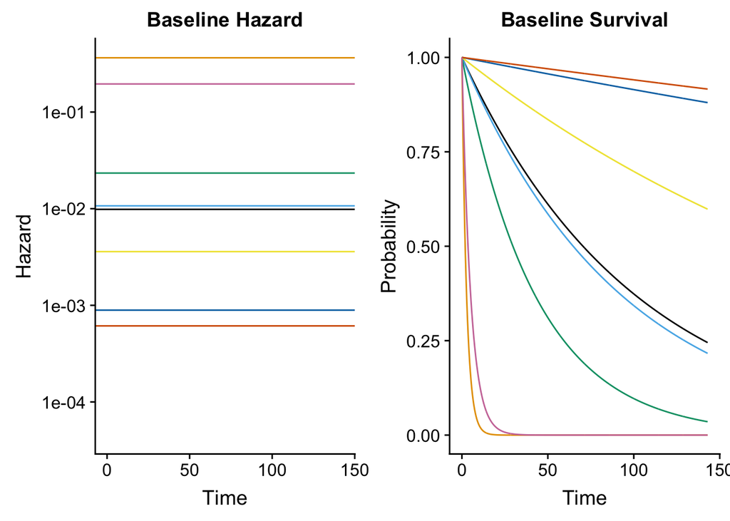

```r
nprior_samples <- 8
icpt_samples <- exp(rnorm(nprior_samples, -5, 2))
# TODO: Replace with direct calls to surv_const_t
df_plot <- map_dfr(1:nprior_samples, ~tibble(time=seq(0, time_max, length.out = 1000), surv=exp(-time*icpt_samples[.]), sample=.))
p1<- ggplot(data=tibble(bhazards=icpt_samples, sample=as.factor(1:nprior_samples)))+
  scale_y_log10(name="Hazard", limits=exp(c(-10, -1))) +
  scale_x_continuous(name="Time", limits=c(0,time_max))+
  geom_hline(aes(yintercept=bhazards, color=sample))+
  guides( color=FALSE)+
  scale_fill_manual(values=cbbPalette)+
  scale_colour_manual(values=cbbPalette)+
  ggtitle("Baseline Hazard")
p2 <- ggplot(data=df_plot)+
  geom_line(aes(x=time, y=surv, color=as.factor(sample)))+
  guides( color=FALSE)+
  scale_fill_manual(values=cbbPalette)+
  scale_colour_manual(values=cbbPalette)+
  xlab("Time")+
  ylab("Probability")+
  ggtitle("Baseline Survival")

cowplot::plot_grid(p1,p2,ncol=2)
```

## Time dependent baseline hazard (aka M-Spline)

This model allows for a time-dependent baseline hazard using M-splines

> Ramsay, James O. “Monotone regression splines in action.” Statistical science 3.4 (1988): 425-441.

```r
ninterior_knots <- 10 # needs to be > 1
# quantile based
knots <- quantile(times,head(tail(seq(0,1, length.out = ninterior_knots+2),-1),-1)) # usually we use times[!msk_censored] instead of times!
dirichlet_alpha<- 1.5
nknots <- length(knots)
mspline_degree<- 3

times_plot <- 0:time_max
isp_plot <- iSpline(times_plot, knots=knots, degree=mspline_degree,
                                intercept=FALSE,Boundary.knots = c(0, max(time_max)))
msp_plot <- deriv(isp_plot)
nsimplex_samps <- 8
nbasis <- dim(isp_plot)[2]

simplex_samples <- t(MCMCpack::rdirichlet(nsimplex_samps, rep(dirichlet_alpha,nbasis)))
icpt_samples <- exp(rnorm(nsimplex_samps, 0, 2))

isp_plot_2 <- isp_plot %*% simplex_samples
msp_plot_2 <- msp_plot %*% simplex_samples
isp_plot <- as.tibble(as.data.frame(as.matrix(isp_plot_2)))
msp_plot <- as.tibble(as.data.frame(as.matrix(msp_plot_2)))
names(icpt_samples) <- colnames(isp_plot)
isp_plot <- map_dfr(colnames(isp_plot), ~tibble(y=pull(isp_plot, .)*icpt_samples[[.]], time=times_plot, basis=.))
msp_plot <- map_dfr(colnames(msp_plot), ~tibble(y=pull(msp_plot, .)*icpt_samples[[.]], time=times_plot, basis=.))
```

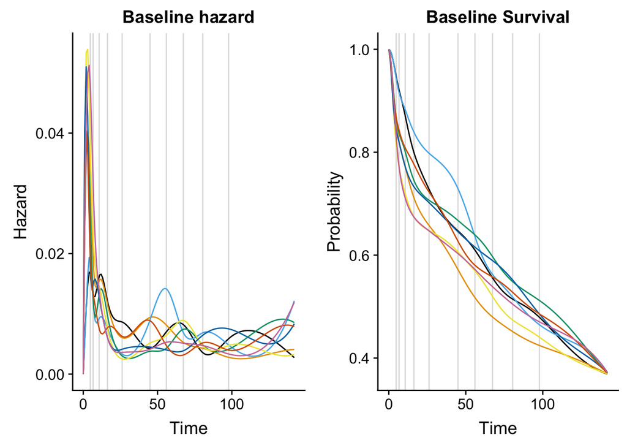

```r
# TODO: Replace with direct calls to surv_mspline_t
p1 <- ggplot(data=mutate(map_dfr(1:nsimplex_samps, ~tibble(y=msp_plot_2[,.], time=times_plot, sample=.)), sample=as.factor(sample)))+
  geom_vline(xintercept = knots, alpha=.5, color='gray')+
  geom_line(mapping = aes(x=time, y=y, color=sample))+
  ggtitle("Baseline hazard")+
  xlab("Time")+
  ylab("Hazard")+
  guides( color=FALSE)+
  scale_fill_manual(values=cbbPalette)+
  scale_colour_manual(values=cbbPalette)


# p2<- ggplot(data=mutate(map_dfr(1:nsimplex_samps, ~tibble(y=isp_plot_2[,.], time=times_plot, sample=.)), sample=as.factor(sample)))+
#   geom_vline(xintercept = knots, alpha=.5, color='gray')+
#   geom_line(mapping = aes(x=time, y=y, color=sample))+
#   ggtitle("Cumulative Baseline hazard")+
#   xlab("Time")+
#   ylab("Cumulative Hazard")+
#   guides( color=FALSE)+
#   scale_fill_manual(values=cbbPalette)+
#   scale_colour_manual(values=cbbPalette)

p3<- ggplot(data=mutate(map_dfr(1:nsimplex_samps, ~tibble(y=exp(-isp_plot_2[,.]), time=times_plot, sample=.)), sample=as.factor(sample)))+
  geom_vline(xintercept = knots, alpha=.5, color='gray')+
  geom_line(mapping = aes(x=time, y=y, color=sample))+
  ggtitle("Baseline Survival")+
  xlab("Time")+
  ylab("Probability")+
  guides( color=FALSE)+
  scale_fill_manual(values=cbbPalette)+
  scale_colour_manual(values=cbbPalette)

cowplot::plot_grid(p1,p3,ncol=2)
```

```r
i_spline_basis_evals <- iSpline(times, knots=knots, degree=mspline_degree,
                                intercept=FALSE, Boundary.knots = c(0, time_max))
m_spline_basis_evals <- deriv(i_spline_basis_evals)
i_spline_basis_evals_censored <- i_spline_basis_evals[msk_censored,]
i_spline_basis_evals_uncensored <- i_spline_basis_evals[!msk_censored,]
m_spline_basis_evals_uncensored <- m_spline_basis_evals[!msk_censored,]
nbasis <- dim(i_spline_basis_evals_censored)[2]




stan_data <- list(N_uncensored=N-N_censored,
                  N_censored=N_censored,
                  X_censored=as.matrix(X[msk_censored,]),
                  X_uncensored=as.matrix(X[!msk_censored,]),
                  times_censored=times[msk_censored],
                  times_uncensored = times[!msk_censored],
                  NC=ncol(X),
                  m=nbasis,
                  m_spline_basis_evals_uncensored=m_spline_basis_evals_uncensored,
                  i_spline_basis_evals_uncensored=i_spline_basis_evals_uncensored,
                  i_spline_basis_evals_censored=i_spline_basis_evals_censored,
                  alpha=1.5
)

fit <- sampling(sm, data=stan_data, seed=42, chains=4, cores=2, iter=4000)
fit2 <- sampling(sm2, data=stan_data, seed=42, chains=4, cores=2, iter=4000)

post <- as.array(fit)
post2 <- as.array(fit2)
```

# Posterior

## Constant

```r
broom::tidy(fit, conf.int=T) %>% filter(! term %in%  c(sprintf("times_uncensored_sampled[%d]", 1:stan_data$N_uncensored),
                                                       sprintf("log_lik[%d]", 1:N)
                                                       ))
```

| term | estimate | std.error | conf.low | conf.high |
| --- | --- | --- | --- | --- |
| betas[1] | 0.40669396 | 0.1682257 | 0.07361893 | 0.7289444 |
| betas[2] | 0.06003273 | 0.1590101 | -0.24096045 | 0.3826570 |
| intercept | -6.22266135 | 0.1338910 | -6.49274218 | -5.9703030 |

## M-spline

```r
broom::tidy(fit2, conf.int=T) %>% filter(! term %in%  sprintf("log_lik[%d]", 1:N))
```

| term | estimate | std.error | conf.low | conf.high |
| --- | --- | --- | --- | --- |
| gammas[1] | 0.007123553 | 0.005850071 | 0.0005266367 | 0.02185491 |
| gammas[2] | 0.231523097 | 0.048506546 | 0.1394884410 | 0.33042424 |
| gammas[3] | 0.293077775 | 0.063298943 | 0.1751710438 | 0.42210390 |
| gammas[4] | 0.129358044 | 0.038900671 | 0.0585231579 | 0.20898844 |
| gammas[5] | 0.041350406 | 0.025574072 | 0.0043416152 | 0.10183919 |
| gammas[6] | 0.043583618 | 0.023131129 | 0.0065749353 | 0.09577413 |
| gammas[7] | 0.024007460 | 0.016576578 | 0.0024161001 | 0.06474402 |
| gammas[8] | 0.016091000 | 0.012491856 | 0.0012734963 | 0.04759061 |
| gammas[9] | 0.017428262 | 0.014102410 | 0.0012812381 | 0.05313241 |
| gammas[10] | 0.027284834 | 0.022212408 | 0.0018188353 | 0.08422493 |

[output cut: 6 more lines]

## Hazards

### M-Spline

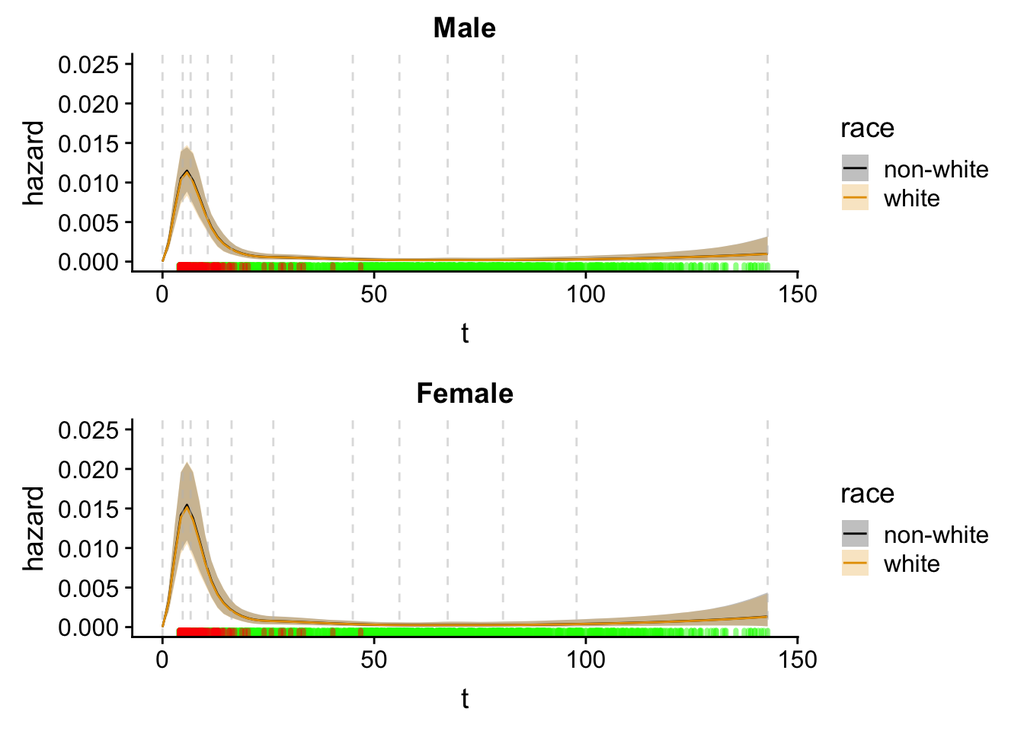

```r
intercepts <- as.vector(post2[,,"intercept"])
betas <- t(matrix(post2[,,sprintf("betas[%d]" ,1:ncol(X))], dim(post2)[1]*dim(post2)[2], ncol(X)))
gammas <- t(matrix(post2[,,sprintf("gammas[%d]", 1:nbasis)], dim(post2)[1]*dim(post2)[2], nbasis))

X_surv = matrix(c(0,0, 0,1, 1,0, 1,1),nrow=4, byrow = T)
times_plot <- seq(0, time_max, length.out = 100)
i_spline_basis_evals <- iSpline(times_plot, knots=knots, degree=mspline_degree,
                                intercept=FALSE, Boundary.knots = c(0, time_max))
m_spline_basis_evals <- deriv(i_spline_basis_evals)
hazards <- purrr::map(1:length(times_plot), ~rowMeans(hazard_mspline_t(m_spline_basis_evals[.,], X_surv, gammas, intercepts, betas)))
quantile_func <- function(x, probs) {
  x <- as.data.frame(t(x))
  map_dbl(x, ~quantile(., probs=probs))
}
hazards_low <- purrr::map(1:length(times_plot), ~quantile_func(hazard_mspline_t(m_spline_basis_evals[.,], X_surv, gammas, intercepts, betas),probs=c(0.025)))
hazards_up <- purrr::map(1:length(times_plot), ~quantile_func(hazard_mspline_t(m_spline_basis_evals[.,], X_surv, gammas, intercepts, betas),probs=c(0.975)))
hazard_df <- dplyr::bind_rows(
  tibble(
  t=times_plot,
  race="white",
  sex="male",
  hazard=map_dbl(hazards, ~.[[1]]),
  hazard_low=map_dbl(hazards_low,~.[[1]]),
  hazard_up=map_dbl(hazards_up,~.[[1]])
  ),
    tibble(
  t=times_plot,
  race="non-white",
  sex="male",
  hazard=map_dbl(hazards, ~.[[2]]),
  hazard_low=map_dbl(hazards_low,~.[[2]]),
  hazard_up=map_dbl(hazards_up,~.[[2]])
  ),
    tibble(
  t=times_plot,
  race="white",
  sex="female",
  hazard=map_dbl(hazards, ~.[[3]]),
  hazard_low=map_dbl(hazards_low,~.[[3]]),
  hazard_up=map_dbl(hazards_up,~.[[3]])
  ),
    tibble(
  t=times_plot,
  race="non-white",
  sex="female",
  hazard=map_dbl(hazards, ~.[[4]]),
  hazard_low=map_dbl(hazards_low,~.[[4]]),
  hazard_up=map_dbl(hazards_up,~.[[4]])
  )
  )


  p1<- ggplot(data=filter(hazard_df, sex=="male")) +
  geom_ribbon(mapping=aes(x=t,ymin=hazard_low, ymax=hazard_up, fill=race), alpha=.25)+
  geom_line(mapping=aes(x=t, y=hazard, color=race))+
  geom_vline(xintercept = c(0,knots, time_max), alpha=.5, color='gray', linetype='dashed')+
  geom_rug(data=tibble(times=times[is_censored]), aes(x=times), col="green",alpha=0.5, size=1.25)+
  geom_rug(data=tibble(times=times[!is_censored]), aes(x=times), col="red",alpha=0.5, size=1.25)+
  scale_fill_manual(values=cbbPalette)+
  scale_colour_manual(values=cbbPalette)+
  ggtitle("Male")+
  ylim(c(0,0.025))

  p2<- ggplot(data=filter(hazard_df, sex=="female")) +
  geom_ribbon(mapping=aes(x=t,ymin=hazard_low, ymax=hazard_up, fill=race), alpha=.25)+
  geom_line(mapping=aes(x=t, y=hazard, color=race))+
  geom_vline(xintercept = c(0,knots, time_max), alpha=.5, color='gray', linetype='dashed')+
  geom_rug(data=tibble(times=times[is_censored]), aes(x=times), col="green",alpha=0.5, size=1.25)+
  geom_rug(data=tibble(times=times[!is_censored]), aes(x=times), col="red",alpha=0.5, size=1.25)+
  scale_fill_manual(values=cbbPalette)+
  scale_colour_manual(values=cbbPalette)+
  ggtitle("Female")+
  ylim(c(0,0.025))

  cowplot::plot_grid(p1,p2, ncol=1)
```

```r
  hazard_df
```

| t | race | sex | hazard | hazard_low | hazard_up |
| --- | --- | --- | --- | --- | --- |
| 0.000000 | white | male | 0.0000000000 | 0.000000e+00 | 0.0000000000 |
| 1.443919 | white | male | 0.0023499371 | 1.477329e-03 | 0.0034532174 |
| 2.887837 | white | male | 0.0066170874 | 4.391541e-03 | 0.0093680471 |
| 4.331756 | white | male | 0.0103290723 | 7.303911e-03 | 0.0140481293 |
| 5.775675 | white | male | 0.0112817632 | 8.339071e-03 | 0.0147361844 |
| 7.219593 | white | male | 0.0100364796 | 6.960696e-03 | 0.0137990052 |
| 8.663512 | white | male | 0.0080828879 | 5.449242e-03 | 0.0113318661 |
| 10.107430 | white | male | 0.0059974233 | 4.143332e-03 | 0.0082298560 |
| 11.551349 | white | male | 0.0042713473 | 2.867893e-03 | 0.0060071302 |
| 12.995268 | white | male | 0.0030539650 | 1.851495e-03 | 0.0045529265 |

[output cut: 390 more lines]

### Constant

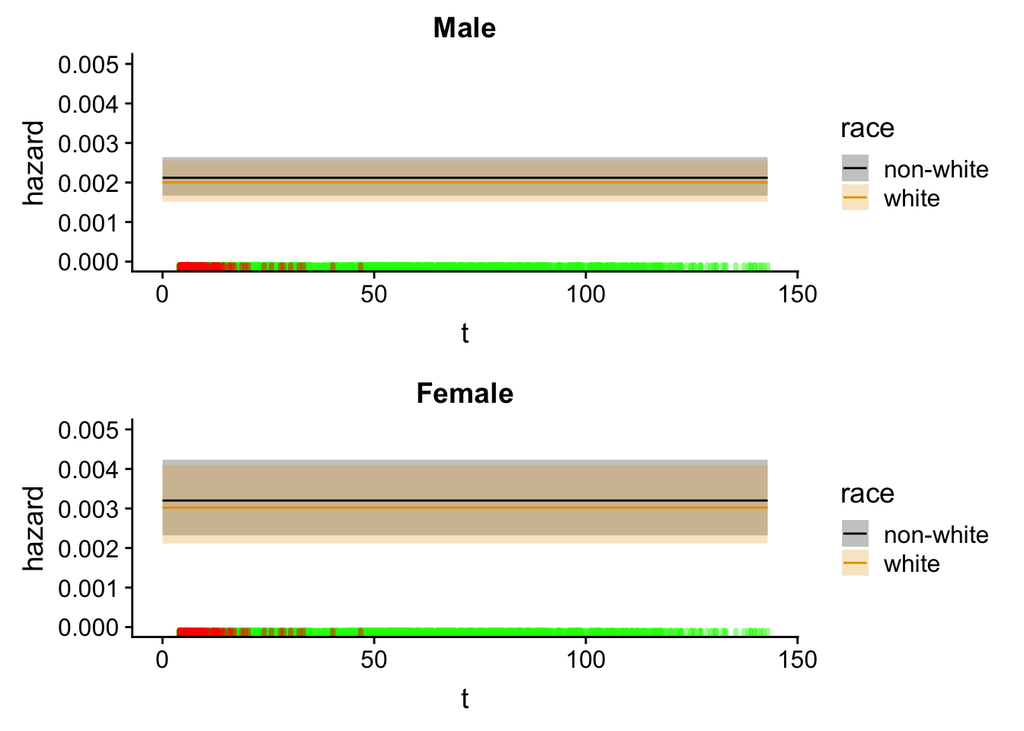

```r
intercepts <- as.vector(post[,,"intercept"])
betas <- t(matrix(post[,,sprintf("betas[%d]" ,1:ncol(X))], dim(post)[1]*dim(post)[2], ncol(X)))

X_surv = matrix(c(0,0, 0,1, 1,0, 1,1),nrow=4, byrow = T)
times_plot <- seq(0, time_max, length.out = 100)

hazards <- purrr::map(times_plot, ~rowMeans(hazard_const_t(., X_surv, intercepts, betas)))
quantile_func <- function(x, probs) {
  x <- as.data.frame(t(x))
  map_dbl(x, ~quantile(., probs=probs))
}
hazards_low <- purrr::map(times_plot, ~quantile_func(hazard_const_t(., X_surv, intercepts, betas),probs=c(0.025)))
hazards_up <- purrr::map(times_plot, ~quantile_func(hazard_const_t(., X_surv, intercepts, betas),probs=c(0.975)))
hazard_df <- dplyr::bind_rows(
  tibble(
  t=times_plot,
  race="white",
  sex="male",
  hazard=map_dbl(hazards, ~.[[1]]),
  hazard_low=map_dbl(hazards_low,~.[[1]]),
  hazard_up=map_dbl(hazards_up,~.[[1]])
  ),
    tibble(
  t=times_plot,
  race="non-white",
  sex="male",
  hazard=map_dbl(hazards, ~.[[2]]),
  hazard_low=map_dbl(hazards_low,~.[[2]]),
  hazard_up=map_dbl(hazards_up,~.[[2]])
  ),
    tibble(
  t=times_plot,
  race="white",
  sex="female",
  hazard=map_dbl(hazards, ~.[[3]]),
  hazard_low=map_dbl(hazards_low,~.[[3]]),
  hazard_up=map_dbl(hazards_up,~.[[3]])
  ),
    tibble(
  t=times_plot,
  race="non-white",
  sex="female",
  hazard=map_dbl(hazards, ~.[[4]]),
  hazard_low=map_dbl(hazards_low,~.[[4]]),
  hazard_up=map_dbl(hazards_up,~.[[4]])
  )
  )


  p1<- ggplot(data=filter(hazard_df, sex=="male")) +
  geom_ribbon(mapping=aes(x=t,ymin=hazard_low, ymax=hazard_up, fill=race), alpha=.25)+
  geom_line(mapping=aes(x=t, y=hazard, color=race))+
  geom_rug(data=tibble(times=times[is_censored]), aes(x=times), col="green",alpha=0.5, size=1.25)+
  geom_rug(data=tibble(times=times[!is_censored]), aes(x=times), col="red",alpha=0.5, size=1.25)+
  scale_fill_manual(values=cbbPalette)+
  scale_colour_manual(values=cbbPalette)+
  ggtitle("Male")+
  ylim(c(0,0.005))

  p2<- ggplot(data=filter(hazard_df, sex=="female")) +
  geom_ribbon(mapping=aes(x=t,ymin=hazard_low, ymax=hazard_up, fill=race), alpha=.25)+
  geom_line(mapping=aes(x=t, y=hazard, color=race))+
  geom_rug(data=tibble(times=times[is_censored]), aes(x=times), col="green",alpha=0.5, size=1.25)+
  geom_rug(data=tibble(times=times[!is_censored]), aes(x=times), col="red",alpha=0.5, size=1.25)+
  scale_fill_manual(values=cbbPalette)+
  scale_colour_manual(values=cbbPalette)+
  ggtitle("Female")+
  ylim(c(0,0.005))

  cowplot::plot_grid(p1,p2, ncol=1)
```

```r
  hazard_df
```

| t | race | sex | hazard | hazard_low | hazard_up |
| --- | --- | --- | --- | --- | --- |
| 0.000000 | white | male | 0.002001701 | 0.001514391 | 0.002553468 |
| 1.443919 | white | male | 0.002001701 | 0.001514391 | 0.002553468 |
| 2.887837 | white | male | 0.002001701 | 0.001514391 | 0.002553468 |
| 4.331756 | white | male | 0.002001701 | 0.001514391 | 0.002553468 |
| 5.775675 | white | male | 0.002001701 | 0.001514391 | 0.002553468 |
| 7.219593 | white | male | 0.002001701 | 0.001514391 | 0.002553468 |
| 8.663512 | white | male | 0.002001701 | 0.001514391 | 0.002553468 |
| 10.107430 | white | male | 0.002001701 | 0.001514391 | 0.002553468 |
| 11.551349 | white | male | 0.002001701 | 0.001514391 | 0.002553468 |
| 12.995268 | white | male | 0.002001701 | 0.001514391 | 0.002553468 |

[output cut: 390 more lines]

## Survival curves

### M-Spline

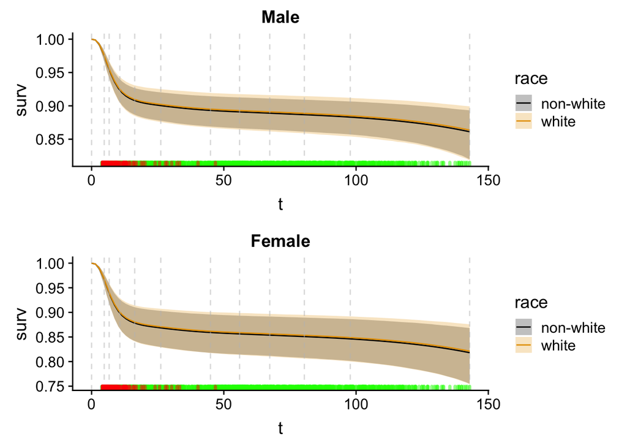

```r
intercepts <- as.vector(post2[,,"intercept"])
betas <- t(matrix(post2[,,sprintf("betas[%d]" ,1:ncol(X))], dim(post2)[1]*dim(post2)[2], ncol(X)))
gammas <- t(matrix(post2[,,sprintf("gammas[%d]", 1:nbasis)], dim(post2)[1]*dim(post2)[2], nbasis))
X_surv = matrix(c(0,0, 0,1, 1,0, 1,1),nrow=4, byrow = T)

times_plot <- seq(0, time_max, length.out = 100)
i_spline_basis_evals <- iSpline(times_plot, knots=knots, degree=mspline_degree,
                                intercept=FALSE, Boundary.knots = c(0, time_max))
quantile_func <- function(x, probs) {
  x <- as.data.frame(t(x))
  map_dbl(x, ~quantile(., probs=probs))
}
survs <- purrr::map(1:length(times_plot), ~rowMeans(surv_mspline_t(i_spline_basis_evals[.,], X_surv, gammas, intercepts, betas)))
survs_low <- purrr::map(1:length(times_plot), ~quantile_func(surv_mspline_t(i_spline_basis_evals[.,], X_surv, gammas, intercepts, betas),probs=c(0.025)))
survs_up <- purrr::map(1:length(times_plot), ~quantile_func(surv_mspline_t(i_spline_basis_evals[.,], X_surv, gammas, intercepts, betas),probs=c(0.975)))

surv_df <- dplyr::bind_rows(
  tibble(
  t=times_plot,
  race="white",
  sex="male",
  surv=map_dbl(survs, ~.[[1]]),
  surv_low=map_dbl(survs_low,~.[[1]]),
  surv_up=map_dbl(survs_up,~.[[1]])
  ),
    tibble(
  t=times_plot,
  race="non-white",
  sex="male",
  surv=map_dbl(survs, ~.[[2]]),
  surv_low=map_dbl(survs_low,~.[[2]]),
  surv_up=map_dbl(survs_up,~.[[2]])
  ),
    tibble(
  t=times_plot,
  race="white",
  sex="female",
  surv=map_dbl(survs, ~.[[3]]),
  surv_low=map_dbl(survs_low,~.[[3]]),
  surv_up=map_dbl(survs_up,~.[[3]])
  ),
    tibble(
  t=times_plot,
  race="non-white",
  sex="female",
  surv=map_dbl(survs, ~.[[4]]),
  surv_low=map_dbl(survs_low,~.[[4]]),
  surv_up=map_dbl(survs_up,~.[[4]])
  )
  )


  p1<- ggplot(data=filter(surv_df, sex=="male")) +
  geom_ribbon(mapping=aes(x=t,ymin=surv_low, ymax=surv_up, fill=race), alpha=.25)+
  geom_line(mapping=aes(x=t, y=surv, color=race))+
  geom_vline(xintercept = c(0,knots, time_max), alpha=.5, color='gray', linetype='dashed')+
  geom_rug(data=tibble(times=times[is_censored]), aes(x=times), col="green",alpha=0.5, size=1.25)+
  geom_rug(data=tibble(times=times[!is_censored]), aes(x=times), col="red",alpha=0.5, size=1.25)+
  scale_fill_manual(values=cbbPalette)+
  scale_colour_manual(values=cbbPalette)+
  ggtitle("Male")

  p2<- ggplot(data=filter(surv_df, sex=="female")) +
  geom_ribbon(mapping=aes(x=t,ymin=surv_low, ymax=surv_up, fill=race), alpha=.25)+
  geom_line(mapping=aes(x=t, y=surv, color=race))+
  geom_vline(xintercept = c(0,knots, time_max), alpha=.5, color='gray', linetype='dashed')+
  geom_rug(data=tibble(times=times[is_censored]), aes(x=times), col="green",alpha=0.5, size=1.25)+
  geom_rug(data=tibble(times=times[!is_censored]), aes(x=times), col="red",alpha=0.5, size=1.25)+
  scale_fill_manual(values=cbbPalette)+
  scale_colour_manual(values=cbbPalette)+
  ggtitle("Female")

  cowplot::plot_grid(p1,p2, ncol=1)
```

```r
  surv_df
```

| t | race | sex | surv | surv_low | surv_up |
| --- | --- | --- | --- | --- | --- |
| 0.000000 | white | male | 1.0000000 | 1.0000000 | 1.0000000 |
| 1.443919 | white | male | 0.9986838 | 0.9979406 | 0.9992116 |
| 2.887837 | white | male | 0.9923218 | 0.9889561 | 0.9950310 |
| 4.331756 | white | male | 0.9800496 | 0.9721441 | 0.9865050 |
| 5.775675 | white | male | 0.9645146 | 0.9520336 | 0.9747818 |
| 7.219593 | white | male | 0.9496613 | 0.9340292 | 0.9627359 |
| 8.663512 | white | male | 0.9372874 | 0.9191264 | 0.9529026 |
| 10.107430 | white | male | 0.9278335 | 0.9075390 | 0.9455239 |
| 11.551349 | white | male | 0.9210495 | 0.8990715 | 0.9403008 |
| 12.995268 | white | male | 0.9162479 | 0.8931262 | 0.9363210 |

[output cut: 390 more lines]